# Economía del Conocimiento en La Rioja

Análisis del período 2019-2025

Autor/a

Lic. en Economía

Fecha de publicación

septiembre 2026

# 1 Resumen ejecutivo

El sector de la Economía del Conocimiento (EC) en La Rioja presenta una dinámica dual: **crece en términos fiscales y salariales, pero se achica en cantidad de empresas y puestos de trabajo**. Entre 2019 y 2025, el sector consolidó un diferencial salarial creciente y se transformó en el único vector positivo dentro de la recaudación provincial de Ingresos Brutos. Al mismo tiempo, perdió masa crítica empresarial y empleo, ubicándose entre las jurisdicciones con peor desempeño relativo del país.

Los seis hallazgos principales:

1. **Recaudación EC: crecimiento ×32,9 en cuatro años.** La porción de Ingresos Brutos atribuible a actividades EC pasó de $58,99 M (2022) a $1.940,91 M (2025). Su peso sobre la base imponible provincial se triplicó: de 0,51% a 1,55%. Es el agregado que más rápido crece dentro del sistema tributario provincial.
2. **Prima salarial: el núcleo informático paga +66,5% sobre el promedio provincial.** El diferencial se duplicó entre 2022 (+27,2%) y 2025 (+66,5%). La rama Informática n.c.p. (CIIU 7290) paga más del doble del promedio provincial (+100,5% en dic-2025).
3. **Empresas EC: caída de −11,6% entre 2022 y 2025.** La cantidad de empresas del sector pasó de 95 (2022) a 84 (2025, preliminar), tras haber alcanzado 102 en 2024. La tendencia se revirtió después del pico.
4. **Empleo EC: −23,7% desde el pico 2023.** El empleo del núcleo informático (CIIU 7220 + 7290) pasó de 78 puestos en 2023 a 59,5 en 2025. Su participación en el empleo formal provincial es de 0,22%.
5. **Intensidad empresarial: la peor caída del país.** La Rioja perdió −4,45 pp de intensidad EC entre 2022 y 2025, el peor desempeño entre 9 jurisdicciones comparadas. Pasó de 33,07‰ a 28,62‰.
6. **Elasticidad invertida.** Entre 2022 y 2024, las empresas EC crecieron +7,4% mientras el empleo del núcleo **cayó −6,5%**: cada empresa EC emplea menos trabajadores. El tamaño medio se redujo de 0,69 a 0,60 empleados por empresa.

**Diagnóstico general.** El sector EC de La Rioja opera como un **enclave de altos salarios sobre una base empresarial frágil**. La recaudación y los salarios crecen, pero la cantidad de empresas y empleos retroceden. El 67,7% del conteo de empresas EC depende de dos códigos proxy (arquitectura/ingeniería y servicios empresariales) que pagan por debajo del promedio provincial. El núcleo informático real (CIIU 7220 y 7290) representa una fracción minoritaria del sector.

# 2 Análisis

## 2.1 Definición y magnitud del sector

El análisis adopta la definición de **Actividades EC (AFIP/ARCA)**, que identifica las actividades de Economía del Conocimiento a partir de los códigos CIIU rev. 3 equivalentes a las promovidas por la Ley 27.506 y su modificatoria 27.570. Incluye ocho códigos: 7210, 7220, 7250, 7290, 7300, 7421, 7430 y 7499.

Dentro de esa definición amplia, este informe distingue el **núcleo informático** (CIIU 7210, 7220 y 7290), que constituye la definición canónica del análisis. En la práctica se calcula como la suma de 7220 y 7290, porque el código 7210 no tiene datos publicados en los archivos SIPA-OEDE de 4 dígitos.

**Nota**

**Advertencia metodológica.** Los códigos 7421 (arquitectura, ingeniería y geología) y 7499 (servicios empresariales n.c.p.) son **proxies**: el SIPA no permite aislar la actividad EC específica dentro de ellos. Bajo la definición amplia, el **67,7% del conteo EC depende de estos dos códigos**. El conteo es un **techo superior**, no exacto.

En 2024, el sector EC de La Rioja registró **102 empresas** (3,13% del total provincial) y **61 puestos de trabajo del núcleo informático** en promedio anual. La densidad empresarial del sector es de **31,34‰**, ubicándose en el 7° puesto entre 9 jurisdicciones comparadas.

## 2.2 Dinámica empresarial 2019-2025

[output not shown]

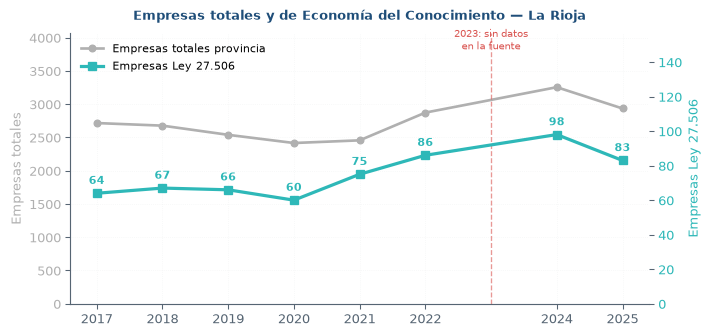

| Año | Total EC | Share del total provincial |
| --- | --- | --- |
| 2019 | 70 | 2,76% |
| 2020 | 65 | 2,69% |
| 2021 | 74 | 3,01% |
| 2022 | 95 | 3,31% |
| 2023 | *s/d* | — |
| 2024 | 102 | 3,13% |
| 2025 (prelim.) | 84 | 2,86% |

La serie muestra tres fases:

1. **2019-2021:** crecimiento moderado, de 70 a 74 empresas.
2. **2022-2024:** salto y consolidación, hasta un pico de 102 empresas en 2024.
3. **2025:** reversión. La cantidad cae a 84 empresas (−17,6% respecto al pico).

La fuente no publica datos para 2023, lo que impide reconstruir la trayectoria exacta entre 2022 y 2024.

### 2.2.1 Composición por bloque

| Bloque | 2019 | 2020 | 2021 | 2022 | 2024 | 2025 |
| --- | --- | --- | --- | --- | --- | --- |
| Software y SI | 6 | 11 | 17 | 25 | 28 | 25 |
| Ingeniería y geología (proxy) | 29 | 22 | 25 | 26 | 31 | 28 |
| Servicios profesionales (proxy) | 29 | 32 | 28 | 40 | 38 | 31 |
| Publicidad | 6 | 0 | 4 | 4 | 5 | 0 |

El **software** se estancó entre 2022 y 2025 (25 → 28 → 25). La **publicidad** colapsó a 0 en 2025. Los **proxies** (7421 y 7499) concentran el 67,7% del conteo total del sector.

### 2.2.2 Intensidad empresarial: comparación regional

| Provincia | 2022 | 2024 | 2025 | Δ pp (22→25) |
| --- | --- | --- | --- | --- |
| CABA | 67,30 | 67,95 | 68,64 | +1,34 |
| Catamarca | 39,18 | 43,18 | 44,69 | +5,51 |
| Salta | 37,46 | 38,99 | 42,11 | +4,65 |
| Tucumán | 34,93 | 35,74 | 34,88 | −0,05 |
| Córdoba | 32,81 | 34,55 | 33,90 | +1,09 |
| Jujuy | 31,32 | 33,12 | 32,22 | +0,90 |
| **La Rioja** | **33,07** | **31,34** | **28,62** | **−4,45** |
| Santa Fe | 27,06 | 27,29 | 27,18 | +0,12 |
| Santiago del Estero | 24,31 | 25,63 | 22,24 | −2,07 |

**Fuente:** SIPA-OEDE. Intensidad = (empresas EC / empresas totales) × 1.000.

## 2.3 Empleo EC

El empleo EC se calcula con la definición de núcleo informático (CIIU 7210, 7220, 7290), consistente con el resto del análisis. La serie se construye como **stock promedio anual de puestos de trabajo**, calculado como el promedio de los cuatro trimestres de cada año.

| Año | Empleo EC (núcleo) | Empleo total provincial | Participación |
| --- | --- | --- | --- |
| 2019 | 11,5 | 26.894 | 0,043% |
| 2020 | 23,75 | 25.399 | 0,094% |
| 2021 | 29,0 | 26.245 | 0,110% |
| 2022 | 65,5 | 30.125 | 0,217% |
| 2023 | 78,0 | 32.701 | 0,239% |
| 2024 | 61,25 | 28.008 | 0,219% |
| 2025 | 59,5 | 27.047 | 0,220% |

**Fuente:** SIPA-OEDE (STEySS), CIIU 7220 + 7290.

El empleo del núcleo informático pasó de **11,5** (2019) a **59,5** puestos (2025), un aumento de **+417%**. El pico se registró en **2023** con 78 puestos (0,239% del empleo provincial). Desde entonces, el empleo cayó **−23,7%** en dos años. La participación en el empleo formal provincial pasó de 0,04% a 0,22%: se multiplicó por 5,5.

### 2.3.1 Elasticidad empresas-empleo

| Año | Empresas EC (índice 2022=100) | Empleo EC (índice 2022=100) |
| --- | --- | --- |
| 2022 | 100,0 | 100,0 |
| 2023 | *s/d* | 119,1 |
| 2024 | 107,4 | 93,5 |
| 2025 | 88,4 | 90,8 |

Entre 2022 y 2024, las empresas EC crecieron +7,4% mientras el empleo del núcleo **cayó −6,5%**. El tamaño medio pasó de **0,69 empleados por empresa** en 2022 a **0,60** en 2024 y **0,71** en 2025.

El patrón de 2025 —caída fuerte de empresas (−17,6%) con caída moderada de empleo (−2,8%)— sugiere **cierre de firmas chicas y concentración en las grandes**. La elasticidad, que en 2024 indicaba un sector que expulsaba empleo, se revirtió parcialmente en 2025 por reducción del denominador.

## 2.4 Salarios y prima salarial EC

### 2.4.1 Salario por CIIU EC (dic-2025)

| CIIU | Rama | Salario | Prima vs. provincial |
| --- | --- | --- | --- |
| 7290 | Informática n.c.p. | $4.220.278 | **+100,5%** |
| 7220 | Consultores informáticos | $2.786.240 | +32,4% |
| 7421 | Arquitectura/ingeniería (proxy) | $1.566.575 | −25,6% |
| 7499 | Servicios empresariales (proxy) | $1.534.016 | −27,1% |
| 7210, 7250, 7300, 7430 | — | sin datos | — |

**Fuente:** SIPA-OEDE, remuneraciones mensuales por CIIU 4 dígitos. Salario provincial de referencia: $2.104.500 (dic-2025, incluye SAC).

Informática n.c.p. paga **+100,5%** sobre el promedio provincial. Las ramas proxy (7421 y 7499) pagan **25-27% por debajo** del promedio. Esto explica por qué la prima del núcleo es sensiblemente mayor que la prima del EC completo.

### 2.4.2 Prima salarial por definición

| Año | Núcleo informático | Núcleo amplio | EC completo |
| --- | --- | --- | --- |
| 2019 | −0,16% | −31,47% | −16,72% |
| 2020 | +46,16% | +46,16% | +18,90% |
| 2021 | +6,16% | −18,35% | −28,51% |
| 2022 | **+27,15%** | −4,62% | −15,39% |
| 2023 | **+62,03%** | +19,78% | −15,09% |
| 2024 | **+63,13%** | +63,13% | +10,22% |
| 2025 | **+66,46%** | +66,46% | **+20,06%** |

La prima del núcleo informático se duplicó entre 2022 (+27,2%) y 2025 (+66,5%). La prima del EC completo es 46 pp menor por el peso de las ramas proxy. La brecha núcleo vs. completo se amplió de 42,5 pp (2022) a 46,4 pp (2025).

**Importante**

## 2.5 Recaudación EC

La **Recaudación EC** es la porción de Ingresos Brutos provincial correspondiente a las actividades de Economía del Conocimiento. No es un impuesto separado: se recauda a través del régimen general de II.BB. La serie se construye a partir del padrón de contribuyentes por régimen (Convenio Multilateral vs. Local) y la base imponible declarada.

### 2.5.1 Serie 2022-2025

| Año | Contrib. Multilateral | Contrib. Locales | Recaudación EC | II.BB total | Share EC |
| --- | --- | --- | --- | --- | --- |
| 2022 | 1.752 | 1.138 | $58,99 M | $11.588,96 M | **0,51%** |
| 2023 | 1.911 | 1.060 | $243,01 M | $26.779,40 M | **0,91%** |
| 2024 | 1.947 | 844 | $846,13 M | $83.422,68 M | **1,01%** |
| 2025 | 2.075 | 840 | **$1.940,91 M** | **$125.549,36 M** | **1,55%** |

**Fuente:** DGIP La Rioja + DNAP/CEPA. II.BB en millones de pesos corrientes.

### 2.5.2 Dinámica comparada

Entre 2022 y 2025, la Recaudación EC creció **×32,9** ($58,99 M → $1.940,91 M), mientras el II.BB total lo hizo **×10,8** ($11.588,96 M → $125.549,36 M). El EC crece **3,0 veces más rápido** que la base total.

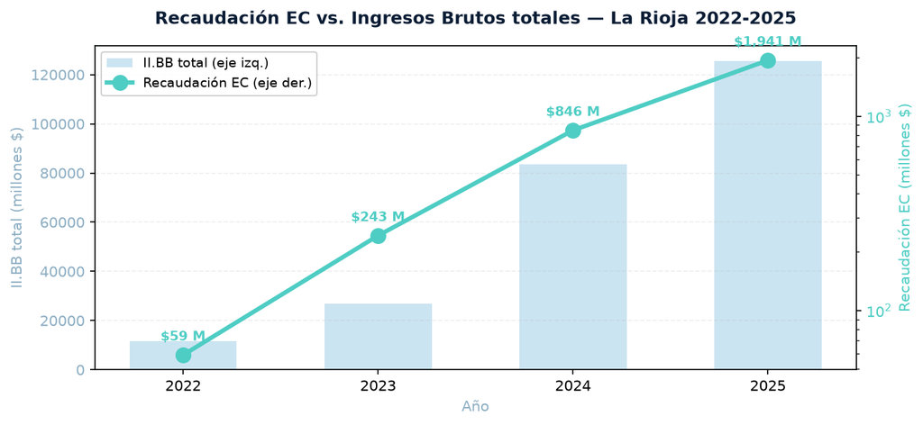

Figura 2: Recaudación EC vs. Ingresos Brutos totales. La Rioja 2022-2025. Fuente: DGIP La Rioja + DNAP/CEPA.

El share del EC sobre la base imponible provincial pasó de **0,51%** (2022) a **1,55%** (2025): se triplicó en cuatro años.

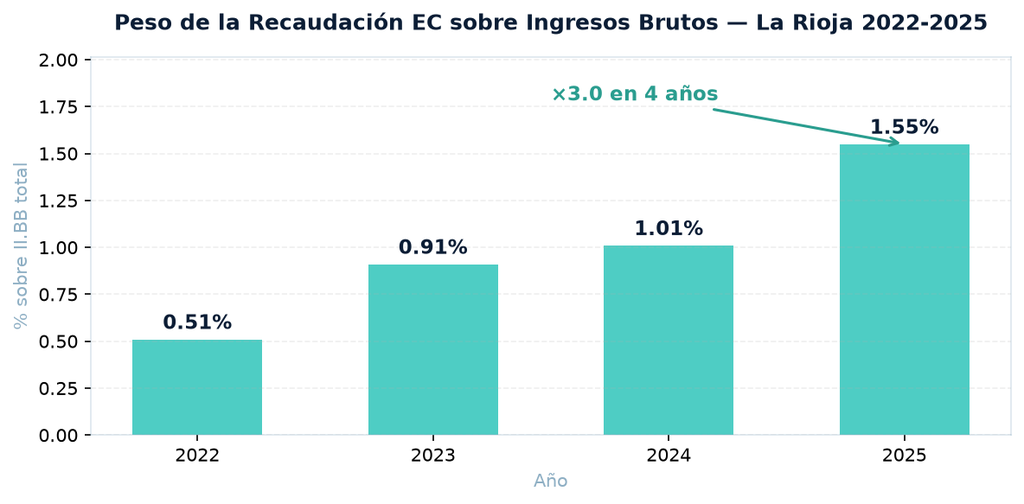

Figura 3: Peso de la Recaudación EC sobre Ingresos Brutos. La Rioja 2022-2025. Fuente: DGIP La Rioja + DNAP/CEPA.

### 2.5.3 Migración de contribuyentes

El padrón EC muestra una recomposición estructural: los contribuyentes **Locales** cayeron −26,2% (1.138 → 840), mientras los de **Convenio Multilateral** crecieron +18,4% (1.752 → 2.075). El share de Multilateral pasó de 60,6% (2022) a 71,2% (2025).

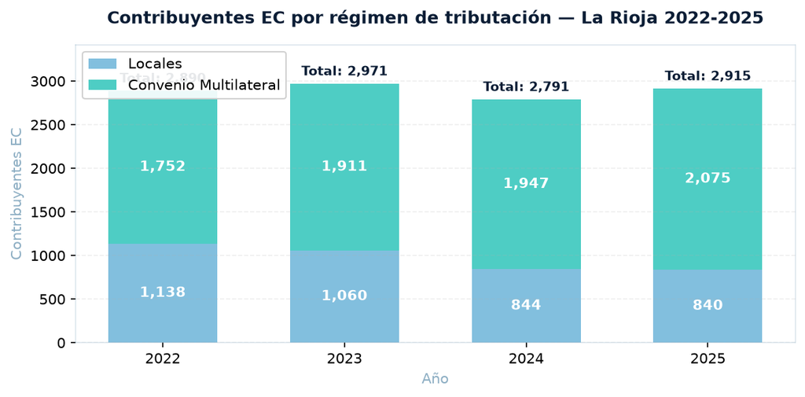

Figura 4: Contribuyentes EC por régimen de tributación. La Rioja 2022-2025. Fuente: DGIP La Rioja.

La caída de contribuyentes Locales no implica desaparición de firmas, sino traspaso al régimen de Convenio Multilateral. Es un patrón esperable cuando las empresas del sector crecen y comienzan a operar en más de una jurisdicción.